# Machine Learning Engineer: Capstone Project

## Project: Image Recognition for multiple attributes

Image recognition is one of the many applications of Machine Learning, it can solve problems for security purposes, object detection, face detection, healthcare, entertainment, among others. This application has an enormous potential to help our society1, so it is important to find new uses for this tool, improve the current methods and get more accurate and useful insights from it. A good example of these applications, is the work done by research of The Chinese University of Hong Kong for face detection using deep learning (https://arxiv.org/abs/1509.06451).

In this project, we will build a Machine Learning Algorithm using CNN to predict from a giving picture if the person is smiling, if is young and if is male or female.

## Dataset

For this project we will use the CelebA dataset (http://mmlab.ie.cuhk.edu.hk/projects/CelebA.html), which is available on Kaggle.

Description of the CelebA dataset from kaggle (https://www.kaggle.com/jessicali9530/celeba-dataset):

### Context

A popular component of computer vision and deep learning revolves around identifying faces for various applications from logging into your phone with your face or searching through surveillance images for a particular suspect. This dataset is great for training and testing models for face detection, particularly for recognising facial attributes such as finding people with brown hair, are smiling, or wearing glasses. Images cover large pose variations, background clutter, diverse people, supported by a large quantity of images and rich annotations. This data was originally collected by researchers at MMLAB, The Chinese University of Hong Kong (specific reference in Acknowledgment section).

### Content

#### Overall

202,599 number of face images of various celebrities 10,177 unique identities, but names of identities are not given 40 binary attribute annotations per image 5 landmark locations

#### Data Files

- **img_align_celeba.zip**: All the face images, cropped and aligned
- **list_eval_partition.csv**: Recommended partitioning of images into training, validation, testing sets. Images 1-162770 are training, 162771-182637 are validation, 182638-202599 are testing
- **list_bbox_celeba.csv**: Bounding box information for each image. "x_1" and "y_1" represent the upper left point coordinate of bounding box. "width" and "height" represent the width and height of bounding box
- **list_landmarks_align_celeba.csv**: Image landmarks and their respective coordinates. There are 5 landmarks: left eye, right eye, nose, left mouth, right mouth
- **list_attr_celeba.csv**: Attribute labels for each image. There are 40 attributes. "1" represents positive while "-1" represents negative

### Import libraries

```python
import pandas as pd
import numpy as np
import cv2
import matplotlib.pyplot as plt
import matplotlib.image as mpimg
import seaborn as sns
import glob
import os
import shutil
from sklearn.metrics import f1_score

from keras.applications.inception_v3 import InceptionV3, preprocess_input
from keras import applications
from keras import optimizers
from keras.models import Sequential, Model
from keras.layers import Dropout, Flatten, Dense, GlobalAveragePooling2D
from keras import backend as k
from keras.callbacks import ModelCheckpoint, LearningRateScheduler, TensorBoard, EarlyStopping
from keras.preprocessing.image import ImageDataGenerator, array_to_img, img_to_array, load_img
from keras.utils import np_utils
from keras.optimizers import SGD

plt.style.use('ggplot')

%matplotlib inline
```

## Step 0: Data Exploration

We will be using the CelebA Dataset, which includes images of 178 x 218 px. Below is an example of how the pictures looks like.

```
Number of faces detected: 1
```

[figure not shown]

```python
EXAMPLE_PIC = 'celeba-dataset/img_align_celeba/000506.jpg'

# extract pre-trained face detector
face_cascade = cv2.CascadeClassifier('haarcascades/haarcascade_frontalface_alt.xml')

# load color (BGR) image
file_name = EXAMPLE_PIC
img = cv2.imread(file_name)

# convert BGR image to grayscale
gray = cv2.cvtColor(img, cv2.COLOR_BGR2GRAY)

# find faces in image
faces = face_cascade.detectMultiScale(gray)

# print number of faces detected in the image
print('Number of faces detected:', len(faces))

# get bounding box for each detected face
for (x,y,w,h) in faces:
    # add bounding box to color image
    cv2.rectangle(img,(x,y),(x+w,y+h),(255,0,0),2)

# convert BGR image to RGB for plotting
cv_rgb = cv2.cvtColor(img, cv2.COLOR_BGR2RGB)

# display the image, along with bounding box
plt.grid(False)
plt.imshow(cv_rgb)
plt.show()
```

We include the Attributes data set in order to get characteristics of the images

```python
# import the data set that include the attribute for each picture
df_attr = pd.read_csv('celeba-dataset/list_attr_celeba.csv')
df_attr.set_index('image_id', inplace=True)
df_attr.replace(to_replace=-1, value=0, inplace=True) #replace -1 by 0
df_attr.shape
```

```
(202599, 40)
```

```python
# List of available attributes
for i, j in enumerate(df_attr.columns):
    print(i, j)
```

```
0 5_o_Clock_Shadow
1 Arched_Eyebrows
2 Attractive
3 Bags_Under_Eyes
4 Bald
5 Bangs
6 Big_Lips
7 Big_Nose
8 Black_Hair
9 Blond_Hair
10 Blurry
11 Brown_Hair
12 Bushy_Eyebrows
13 Chubby
14 Double_Chin
```

[output cut: 25 more lines]

During this project the focues will be over 3 attributes: **Smiling or not, Female or Male and Young or not.**

In the example picture, these are the attributes:

```
Smiling    1
Male       0
Young      1
Name: 000506.jpg, dtype: int64
```

[figure not shown]

```python
# plot picture and attributes
img = load_img(EXAMPLE_PIC)
plt.grid(False)
plt.imshow(img)
df_attr.loc[EXAMPLE_PIC.split('/')[-1]] [['Smiling','Male','Young']]
```

In the example picture, according to the data set, the person is smiling, is female and is young.

```python
# Select the attributies for this project
df_attr = df_attr[['Smiling','Male','Young']]
df_attr.head()
```

| image_id | Smiling | Male | Young |
| --- | --- | --- | --- |
| 000001.jpg | 1 | 0 | 1 |
| 000002.jpg | 1 | 0 | 1 |
| 000003.jpg | 0 | 1 | 1 |
| 000004.jpg | 0 | 0 | 1 |
| 000005.jpg | 0 | 0 | 1 |

### Plot the distribution of the selected attributes

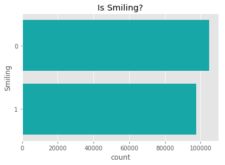

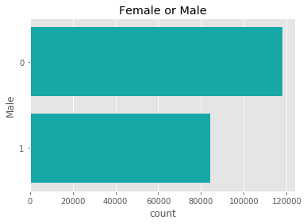

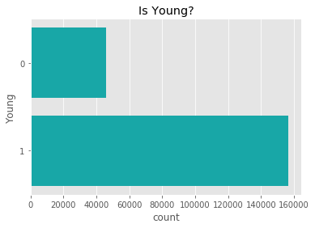

```python
# Plot the selected attributes

# Is Smiling?
plt.title('Is Smiling?')
sns.countplot(y='Smiling', data=df_attr, color="c");
plt.show()

# Female or Male?
plt.title('Female or Male')
sns.countplot(y='Male', data=df_attr, color="c");
plt.show()

# Is Young?
plt.title('Is Young?')
sns.countplot(y='Young', data=df_attr, color="c");
plt.show()
```

#### Some notes:

- **Similing or not**  
  The data set is balanced for this attributes.
- **Female or Male**  
  There are more females than males in the data set.
- **Young or not**  
  Most of the people of the images of the data set are young.

This analysis gives us some signs of how balanced the data is, and how to handle the data to train the models with balanced data.

## Step 1: Pre-processing Images: Data Augmentation

Generates Data Augmentation for iamges.

Data Augmentation allows to generate images with modifications to the original ones. The model will learn from these variations (changing angle, size and position), being able to predict better never seen images that could have the same variations in position, size and position.

```python
# Generate image generator for data augmentation
datagen =  ImageDataGenerator(
  preprocessing_function=preprocess_input,
  rotation_range=30,
  width_shift_range=0.2,
  height_shift_range=0.2,
  shear_range=0.2,
  zoom_range=0.2,
  horizontal_flip=True
)

img = load_img(EXAMPLE_PIC)
x = img_to_array(img)
x = x.reshape((1,) + x.shape)

# Delete path if exists
if os.path.exists('celeba-dataset/data_augmentation_sample'):
    shutil.rmtree('celeba-dataset/data_augmentation_sample')

# Create paths for data augmentation sample
os.makedirs('celeba-dataset/data_augmentation_sample')

#create just 10 pics as example
i = 0
for batch in datagen.flow(x, batch_size=1,
              save_to_dir='celeba-dataset/data_augmentation_sample', save_prefix='data_aug', save_format='jpg'):
    if i == 9:
        break
    i += 1
```

[figure not shown]

```python
# Display Data Augmentation results
aug_files = glob.glob("celeba-dataset/data_augmentation_sample/*.jpg")
plt.figure(figsize=(20,10))
columns = 5
for i, image in enumerate(aug_files):
    plt.subplot(len(aug_files) / columns + 1, columns, i + 1)
    img = load_img(image)
    plt.grid(False)
    plt.imshow(img)
```

The result is a new set of images with modifications from the original one, that allows to the model to learn from these variations in order to take this kind of images during the learning process and predict better never seen images.

## Step 2: Split Dataset into Training, Validation and Test

The recommended partitioning of images into training, validation, testing of the data set is:

- 1-162770 are training
- 162771-182637 are validation
- 182638-202599 are testing

Due to computing resource limitations of the researcher to process all the images, the number of the images has been reduced. Basically, using a Mac Book Pro 2017 (2.9 GHz Intel Core i7, 16 GB RAM and 4 GB GPU) will take over a day to train each model, GPU processing is not supporting for MacOS by tensorflow since realease 1.2 (https://www.tensorflow.org/install/install_mac). Instead the reasearher is using a Windows 10 Machine with 2.9 GHz Intel Core i7, 16GB RAM, 2GB NVIDIA GeForce GTX 950M), which accelerate the process thanks to the use of GPU.

The number of images to be used by each model is:

- Training 20000 images
- Validation 5000 images
- Test 5000 Images

```python
df_partition = pd.read_csv('celeba-dataset/list_eval_partition.csv') #the recommended partition
df_partition.head()
```

|  | image_id | partition |
| --- | --- | --- |
| 0 | 000001.jpg | 0 |
| 1 | 000002.jpg | 0 |
| 2 | 000003.jpg | 0 |
| 3 | 000004.jpg | 0 |
| 4 | 000005.jpg | 0 |

```python
# display counter by partition
# 0 -> TRAINING
# 1 -> VALIDATION
# 2 -> TEST
df_partition['partition'].value_counts().sort_index()
```

```
0    162770
1     19867
2     19962
Name: partition, dtype: int64
```

#### Join the partition and the attributes in the same df

```python
# join the partition with the attributes
df_partition.set_index('image_id', inplace=True)
df_par_attr = df_partition.join(df_attr, how='inner')
df_par_attr.head()
```

| image_id | partition | Smiling | Male | Young |
| --- | --- | --- | --- | --- |
| 000001.jpg | 0 | 1 | 0 | 1 |
| 000002.jpg | 0 | 1 | 0 | 1 |
| 000003.jpg | 0 | 0 | 1 | 1 |
| 000004.jpg | 0 | 0 | 0 | 1 |
| 000005.jpg | 0 | 0 | 0 | 1 |

## Step 2.1: Create folders with selected images for models

Number of images need to be balanced in order to get a good performance for the model, each model will have its own folder of training, validation and test balanced data.

On this degree projects, is explained how imbalanced training data impact on CNNs models:

https://www.kth.se/social/files/588617ebf2765401cfcc478c/PHensmanDMasko_dkand15.pdf

On this step we will create functions that will help us to create the data set for each model. Functions will be executed on each model step in order to avoid confusions.

```python
# Set Variables
TRAINING_SAMPLES = 20000
VALIDATION_SAMPLES = 5000
TEST_SAMPLES = 5000
IMG_WIDTH = 178
IMG_HEIGHT = 218
BATCH_SIZE = 16
NUM_EPOCHS = 20 #25
```

```python
def generate_df(attr):
    '''
    select the sub data sets from the recommended partition randomly
    generates balanced data

    '''

    print('Attribute:', attr)

    df_train = df_par_attr[(df_par_attr['partition'] == 0) & (df_par_attr[attr] == 0)].sample(int(TRAINING_SAMPLES/2)) #file names for training
    df_train = pd.concat([df_train,
                                  df_par_attr[(df_par_attr['partition'] == 0) & (df_par_attr[attr] == 1)].sample(int(TRAINING_SAMPLES/2))]) #file names for training
    print('\ntrain:\n', df_train[attr].value_counts())

    df_val = df_par_attr[(df_par_attr['partition'] == 1) & (df_par_attr[attr] == 0)].sample(int(VALIDATION_SAMPLES/2)) #file names for validation
    df_val = pd.concat([df_val,
                                  df_par_attr[(df_par_attr['partition'] == 1) & (df_par_attr[attr] == 1)].sample(int(VALIDATION_SAMPLES/2))]) #file names for validation
    print('\nvalidation:\n', df_val[attr].value_counts())

    df_test = df_par_attr[(df_par_attr['partition'] == 2) & (df_par_attr[attr] == 0)].sample(int(TEST_SAMPLES/2)) #file names for test
    df_test = pd.concat([df_test,
                                  df_par_attr[(df_par_attr['partition'] == 2) & (df_par_attr[attr] == 1)].sample(int(TEST_SAMPLES/2))]) #file names for test
    print('\ntest:\n', df_test[attr].value_counts())

    return df_train, df_val, df_test
```

```python
# create folders (train, validation and test) for each model
def create_file_folder(prefix):
    '''
    create folders in order to use the flow_from_directory method form keras

    creates folders:
        train/0
        train/1
        validation/0
        validation/1
        test/0
        test/1

    '''

    list_type_ds = ['train', 'validation', 'test']

    # Delete path if exists
    for typ in list_type_ds:
        if os.path.exists('celeba-dataset/{}-{}'.format(prefix, typ)):
            shutil.rmtree('celeba-dataset/{}-{}'.format(prefix, typ))

    # Create paths for training, validation and test data
    for typ in list_type_ds:
        os.makedirs('celeba-dataset/{}-{}'.format(prefix, typ))
        os.makedirs('celeba-dataset/{}-{}/0'.format(prefix, typ))
        os.makedirs('celeba-dataset/{}-{}/1'.format(prefix, typ))

#create_file_folder('young')
```

```python
# copy images to the corresponding folder
def copy_images(folder_prefix, attribute, df_images, df_type):
    '''
    copy images to the corresponding folder (classes)

    folder_prefix: expected prefix in folder
    attribute: attribute as in the data set to discriminate the classes
    df_images: data frame with image file name and attributes
    df_type: type of data set, train, validation or test

    '''

    # Copy images
    for i, j in df_images.iterrows():
        if j[attribute] == 0:
            shutil.copy('celeba-dataset/img_align_celeba/' + i, 'celeba-dataset/{}-{}/0/{}'.format(folder_prefix, df_type, i))
        if j[attribute] == 1:
            shutil.copy('celeba-dataset/img_align_celeba/' + i, 'celeba-dataset/{}-{}/1/{}'.format(folder_prefix, df_type, i))

    print("{} {} - Copy Images: DONE!".format(folder_prefix, df_type))
```

```python
def count_attributes(prefix, reference_class):
    '''
    count image classes for each model

    prefix: expected prefix in folder name
    reference_class: list of str with meaning of each class
    '''

    print('\nData for "{}" Model'.format(prefix))
    list_ds_types = ['train', 'validation', 'test']

    for ty in list_ds_types:
        print('   {} data:'.format(ty))
        print('      {}:'.format(reference_class[0]), len(os.listdir('celeba-dataset/{}-{}/0/'.format(prefix, ty))))
        print('      {}:'.format(reference_class[1]), len(os.listdir('celeba-dataset/{}-{}/1/'.format(prefix, ty))))
```

With the data in their respective folders, we are ready to start modeling.

## Step 3: "Smiling or not" Model

### 3.1. Set the Smile Model

```python
create_file_folder('smile')
print('Generate dataframe with file names for the model')
df_smile_train, df_smile_val, df_smile_test = generate_df('Smiling')
print('\nCopying the images...')
copy_images('smile', 'Smiling', df_smile_train, 'train')
copy_images('smile', 'Smiling', df_smile_val, 'validation')
copy_images('smile', 'Smiling', df_smile_test, 'test')
print('Counter from file')
count_attributes('smile', ['Not Smiling', 'Smiling'])
```

```
Generate dataframe with file names for the model
Attribute: Smiling

train:
 1    10000
0    10000
Name: Smiling, dtype: int64

validation:
 1    2500
0    2500
Name: Smiling, dtype: int64

test:
 1    2500
0    2500
Name: Smiling, dtype: int64

Copying the images...
smile train - Copy Images: DONE!
smile validation - Copy Images: DONE!
smile test - Copy Images: DONE!
Counter from file

Data for "smile" Model
   train data:
      Not Smiling: 10000
      Smiling: 10000
   validation data:
      Not Smiling: 2500
      Smiling: 2500
   test data:
      Not Smiling: 2500
      Smiling: 2500
```

```python
PREFIX = 'smile'
```

```python
# Data Preparation - Data Augmentation with generators
train_datagen =  ImageDataGenerator(
  preprocessing_function=preprocess_input,
  rotation_range=30,
  width_shift_range=0.2,
  height_shift_range=0.2,
  shear_range=0.2,
  zoom_range=0.2,
  horizontal_flip=True
)

valid_datagen = ImageDataGenerator(
  preprocessing_function=preprocess_input,
  rotation_range=30,
  width_shift_range=0.2,
  height_shift_range=0.2,
  shear_range=0.2,
  zoom_range=0.2,
  horizontal_flip=True
)

train_generator = train_datagen.flow_from_directory(
'celeba-dataset/{}-train'.format(PREFIX),
target_size=(IMG_HEIGHT, IMG_WIDTH),
batch_size=BATCH_SIZE,
)

validation_generator = valid_datagen.flow_from_directory(
'celeba-dataset/{}-validation'.format(PREFIX),
target_size=(IMG_HEIGHT, IMG_WIDTH),
class_mode='categorical'
)
```

```
Found 20000 images belonging to 2 classes.
Found 5000 images belonging to 2 classes.
```

```python
# Import InceptionV3 Model
inc_model = InceptionV3(weights='imagenet',
                  include_top=False,
                    input_shape=(IMG_HEIGHT, IMG_WIDTH, 3))
print("number of layers:", len(inc_model.layers))
inc_model.summary()
```

```
number of layers: 311
__________________________________________________________________________________________________
Layer (type)                    Output Shape         Param #     Connected to
==================================================================================================
input_1 (InputLayer)            (None, 218, 178, 3)  0
__________________________________________________________________________________________________
conv2d_1 (Conv2D)               (None, 108, 88, 32)  864         input_1[0][0]
__________________________________________________________________________________________________
batch_normalization_1 (BatchNor (None, 108, 88, 32)  96          conv2d_1[0][0]
__________________________________________________________________________________________________
activation_1 (Activation)       (None, 108, 88, 32)  0           batch_normalization_1[0][0]
__________________________________________________________________________________________________
conv2d_2 (Conv2D)               (None, 106, 86, 32)  9216        activation_1[0][0]
__________________________________________________________________________________________________
batch_normalization_2 (BatchNor (None, 106, 86, 32)  96          conv2d_2[0][0]
__________________________________________________________________________________________________
activation_2 (Activation)       (None, 106, 86, 32)  0           batch_normalization_2[0][0]
__________________________________________________________________________________________________
conv2d_3 (Conv2D)               (None, 106, 86, 64)  18432       activation_2[0][0]
__________________________________________________________________________________________________
batch_normalization_3 (BatchNor (None, 106, 86, 64)  192         conv2d_3[0][0]
__________________________________________________________________________________________________
activation_3 (Activation)       (None, 106, 86, 64)  0           batch_normalization_3[0][0]
__________________________________________________________________________________________________
max_pooling2d_1 (MaxPooling2D)  (None, 52, 42, 64)   0           activation_3[0][0]
__________________________________________________________________________________________________
conv2d_4 (Conv2D)               (None, 52, 42, 80)   5120        max_pooling2d_1[0][0]
__________________________________________________________________________________________________
batch_normalization_4 (BatchNor (None, 52, 42, 80)   240         conv2d_4[0][0]
__________________________________________________________________________________________________
activation_4 (Activation)       (None, 52, 42, 80)   0           batch_normalization_4[0][0]
__________________________________________________________________________________________________
conv2d_5 (Conv2D)               (None, 50, 40, 192)  138240      activation_4[0][0]
__________________________________________________________________________________________________
batch_normalization_5 (BatchNor (None, 50, 40, 192)  576         conv2d_5[0][0]
__________________________________________________________________________________________________
activation_5 (Activation)       (None, 50, 40, 192)  0           batch_normalization_5[0][0]
__________________________________________________________________________________________________
max_pooling2d_2 (MaxPooling2D)  (None, 24, 19, 192)  0           activation_5[0][0]
__________________________________________________________________________________________________
```

[output cut: 610 more lines]

```
__________________________________________________________________________________________________
concatenate_2 (Concatenate)     (None, 5, 4, 768)    0           activation_92[0][0]
                                                                 activation_93[0][0]
__________________________________________________________________________________________________
activation_94 (Activation)      (None, 5, 4, 192)    0           batch_normalization_94[0][0]
__________________________________________________________________________________________________
mixed10 (Concatenate)           (None, 5, 4, 2048)   0           activation_86[0][0]
                                                                 mixed9_1[0][0]
                                                                 concatenate_2[0][0]
                                                                 activation_94[0][0]
==================================================================================================
Total params: 21,802,784
Trainable params: 21,768,352
Non-trainable params: 34,432
__________________________________________________________________________________________________
```

```python
#Adding custom Layers
x = inc_model.output
x = GlobalAveragePooling2D()(x)
x = Dense(1024, activation="relu")(x)
x = Dropout(0.5)(x)
x = Dense(512, activation="relu")(x)
predictions = Dense(2, activation="softmax")(x)
```

```python
# creating the final model
model_smile = Model(input=inc_model.input, output=predictions)

# Lock initial layers to do not be trained
for layer in model_smile.layers[:52]:
    layer.trainable = False

# compile the model
model_smile.compile(optimizer=SGD(lr=0.0001, momentum=0.9)
                    , loss='categorical_crossentropy'
                    , metrics=['accuracy'])
```

### 3.2. Train Smile Model

```python
#https://keras.io/models/sequential/ fit generator
checkpointer = ModelCheckpoint(filepath='saved_models/weights.best.inc.smile.hdf5',
                               verbose=1, save_best_only=True)
```

```python
model_smile.fit_generator(train_generator
                          , validation_data = validation_generator
                          , steps_per_epoch= TRAINING_SAMPLES/BATCH_SIZE
                          , class_weight='auto'
                          , epochs= NUM_EPOCHS
                          , callbacks=[checkpointer]
                          , verbose=1)
```

```
Epoch 00001: val_loss improved from inf to 0.43661, saving model to saved_models/weights.best.inc.smile.hdf5

Epoch 00002: val_loss improved from 0.43661 to 0.34147, saving model to saved_models/weights.best.inc.smile.hdf5

Epoch 00003: val_loss improved from 0.34147 to 0.30130, saving model to saved_models/weights.best.inc.smile.hdf5

Epoch 00004: val_loss did not improve from 0.30130

Epoch 00005: val_loss improved from 0.30130 to 0.29260, saving model to saved_models/weights.best.inc.smile.hdf5

Epoch 00006: val_loss improved from 0.29260 to 0.27056, saving model to saved_models/weights.best.inc.smile.hdf5

Epoch 00007: val_loss did not improve from 0.27056

Epoch 00008: val_loss improved from 0.27056 to 0.25261, saving model to saved_models/weights.best.inc.smile.hdf5

Epoch 00009: val_loss improved from 0.25261 to 0.24494, saving model to saved_models/weights.best.inc.smile.hdf5

Epoch 00010: val_loss did not improve from 0.24494

Epoch 00011: val_loss improved from 0.24494 to 0.23175, saving model to saved_models/weights.best.inc.smile.hdf5

Epoch 00012: val_loss did not improve from 0.23175

Epoch 00013: val_loss did not improve from 0.23175

Epoch 00014: val_loss did not improve from 0.23175

Epoch 00015: val_loss did not improve from 0.23175

Epoch 00016: val_loss did not improve from 0.23175

Epoch 00017: val_loss did not improve from 0.23175

Epoch 00018: val_loss improved from 0.23175 to 0.22714, saving model to saved_models/weights.best.inc.smile.hdf5

Epoch 00019: val_loss did not improve from 0.22714

Epoch 00020: val_loss improved from 0.22714 to 0.21826, saving model to saved_models/weights.best.inc.smile.hdf5
```

```
<keras.callbacks.History at 0x17894a28898>
```

### 3.3. Model Evaluation

```python
#load the best model
model_smile.load_weights('saved_models/weights.best.inc.smile.hdf5')
```

```python
# Generate test files
def generate_test_data(prefix):
    '''
    Resized pictures to the expected array by the model.
    Converts images to arrays.

    return
        x_test: list of array of images.
        y_test: list of labels of the images
    '''

    x_test = []
    y_test = []

    for i in [0,1]:
        for j in glob.glob("celeba-dataset/{}-test/{}/*.jpg".format(prefix, i)):
            im = cv2.imread(j.replace('\\','/'))
            im = cv2.resize(cv2.cvtColor(im, cv2.COLOR_BGR2RGB), (IMG_WIDTH, IMG_HEIGHT)).astype(np.float32) / 255.0
            im = np.expand_dims(im, axis =0)
            x_test.append(im)
            y_test.append(i)

    return x_test, y_test

x_smile_test, y_smile_test = generate_test_data('smile')
```

```python
# generate prediction
model_predictions = [np.argmax(model_smile.predict(feature)) for feature in x_smile_test ]

# report test accuracy
test_accuracy = 100 * np.sum(np.array(model_predictions)==y_smile_test) / len(model_predictions)
print('Smile Model')
print('Test accuracy: %.4f%%' % test_accuracy)
print('f1_score:', f1_score(y_smile_test, model_predictions))
```

```
Smile Model
Test accuracy: 91.3800%
f1_score: 0.9136791508111355
```

```python
model_smile.save('saved_models/smile_model.h5')
```

## Step 4: "Female or Male" Model

### 4.1. Set the "Female or Male" Model

```python
create_file_folder('gender')

print('Generate dataframe with file names for the model')
df_gender_train, df_gender_val, df_gender_test = generate_df('Male')
print('\nCopying the images...')
copy_images('gender', 'Male', df_gender_train, 'train')
copy_images('gender', 'Male', df_gender_val, 'validation')
copy_images('gender', 'Male', df_gender_test, 'test')
print('Counter from file')
count_attributes('gender', ['Female', 'Male'])
```

```
Generate dataframe with file names for the model
Attribute: Male

train:
 1    10000
0    10000
Name: Male, dtype: int64

validation:
 1    2500
0    2500
Name: Male, dtype: int64

test:
 1    2500
0    2500
Name: Male, dtype: int64

Copying the images...
gender train - Copy Images: DONE!
gender validation - Copy Images: DONE!
gender test - Copy Images: DONE!
Counter from file

Data for "gender" Model
   train data:
      Female: 10000
      Male: 10000
   validation data:
      Female: 2500
      Male: 2500
   test data:
      Female: 2500
      Male: 2500
```

```python
PREFIX = 'gender'
```

```python
#set the data generator
train_generator = train_datagen.flow_from_directory(
'celeba-dataset/{}-train'.format(PREFIX),
target_size=(IMG_HEIGHT, IMG_WIDTH),
batch_size=BATCH_SIZE,
)

validation_generator = valid_datagen.flow_from_directory(
'celeba-dataset/{}-validation'.format(PREFIX),
target_size=(IMG_HEIGHT, IMG_WIDTH),
class_mode='categorical'
)
```

```
Found 20000 images belonging to 2 classes.
Found 5000 images belonging to 2 classes.
```

```python
# creating the final model
model_gender = Model(input=inc_model.input, output=predictions)

# Lock initial layers to do not be trained
for layer in model_gender.layers[:52]:
    layer.trainable = False

# compile the model
model_gender.compile(optimizer=SGD(lr=0.0001, momentum=0.9)
                    , loss='categorical_crossentropy'
                    , metrics=['accuracy'])
```

### 4.2. Train Gender Model

```python
#https://keras.io/models/sequential/ fit generator
gender_checkpointer = ModelCheckpoint(filepath='saved_models/weights.best.inc.gender.hdf5',
                               verbose=1, save_best_only=True)

model_gender.fit_generator(train_generator
                          , validation_data = validation_generator
                          , steps_per_epoch= TRAINING_SAMPLES/BATCH_SIZE
                          , class_weight='auto'
                          , epochs= NUM_EPOCHS
                          , callbacks=[gender_checkpointer]
                          , verbose=1)
```

```
Epoch 00001: val_loss improved from inf to 0.23984, saving model to saved_models/weights.best.inc.gender.hdf5

Epoch 00002: val_loss improved from 0.23984 to 0.20932, saving model to saved_models/weights.best.inc.gender.hdf5

Epoch 00003: val_loss improved from 0.20932 to 0.17265, saving model to saved_models/weights.best.inc.gender.hdf5

Epoch 00004: val_loss improved from 0.17265 to 0.13307, saving model to saved_models/weights.best.inc.gender.hdf5

Epoch 00005: val_loss improved from 0.13307 to 0.12231, saving model to saved_models/weights.best.inc.gender.hdf5

Epoch 00006: val_loss did not improve from 0.12231

Epoch 00007: val_loss did not improve from 0.12231

Epoch 00008: val_loss improved from 0.12231 to 0.11941, saving model to saved_models/weights.best.inc.gender.hdf5

Epoch 00009: val_loss improved from 0.11941 to 0.10053, saving model to saved_models/weights.best.inc.gender.hdf5

Epoch 00010: val_loss did not improve from 0.10053

Epoch 00011: val_loss improved from 0.10053 to 0.09752, saving model to saved_models/weights.best.inc.gender.hdf5

Epoch 00012: val_loss did not improve from 0.09752

Epoch 00013: val_loss did not improve from 0.09752

Epoch 00014: val_loss did not improve from 0.09752

Epoch 00015: val_loss did not improve from 0.09752

Epoch 00016: val_loss improved from 0.09752 to 0.09562, saving model to saved_models/weights.best.inc.gender.hdf5

Epoch 00017: val_loss did not improve from 0.09562

Epoch 00018: val_loss did not improve from 0.09562

Epoch 00019: val_loss did not improve from 0.09562

Epoch 00020: val_loss did not improve from 0.09562
```

```
<keras.callbacks.History at 0x17893bccf28>
```

### 4.3. Model Evaluation

```python
#load the best model
model_gender.load_weights('saved_models/weights.best.inc.gender.hdf5')
```

```python
x_gender_test, y_gender_test = generate_test_data('gender')
```

```python
# generate prediction
model_predictions = [np.argmax(model_gender.predict(feature)) for feature in x_gender_test ]

# report test accuracy
test_accuracy = 100 * np.sum(np.array(model_predictions)==y_gender_test) / len(model_predictions)
print('Gender Model')
print('Test accuracy: %.4f%%' % test_accuracy)
print('f1_score:', f1_score(y_gender_test, model_predictions))
```

```
Gender Model
Test accuracy: 95.5200%
f1_score: 0.9535269709543568
```

```python
model_gender.save('saved_models/gender_model.h5')
```

## Step 5: "Young or not" Model

### 5.1. Set the "Young or not" Model

```python
create_file_folder('young')

print('Generate dataframe with file names for the model')
df_young_train, df_young_val, df_young_test = generate_df('Young')
print('\nCopying the images...')
copy_images('young', 'Young', df_young_train, 'train')
copy_images('young', 'Young', df_young_val, 'validation')
copy_images('young', 'Young', df_young_test, 'test')
print('Counter from file')
count_attributes('young', ['Not Young', 'Young'])
```

```
Generate dataframe with file names for the model
Attribute: Young

train:
 1    10000
0    10000
Name: Young, dtype: int64

validation:
 1    2500
0    2500
Name: Young, dtype: int64

test:
 1    2500
0    2500
Name: Young, dtype: int64

Copying the images...
young train - Copy Images: DONE!
young validation - Copy Images: DONE!
young test - Copy Images: DONE!
Counter from file

Data for "young" Model
   train data:
      Not Young: 10000
      Young: 10000
   validation data:
      Not Young: 2500
      Young: 2500
   test data:
      Not Young: 2500
      Young: 2500
```

```python
PREFIX = 'young'
```

```python
#set the data generator
train_generator = train_datagen.flow_from_directory(
'celeba-dataset/{}-train'.format(PREFIX),
target_size=(IMG_HEIGHT, IMG_WIDTH),
batch_size=BATCH_SIZE,
)

validation_generator = valid_datagen.flow_from_directory(
'celeba-dataset/{}-validation'.format(PREFIX),
target_size=(IMG_HEIGHT, IMG_WIDTH),
class_mode='categorical'
)
```

```
Found 20000 images belonging to 2 classes.
Found 5000 images belonging to 2 classes.
```

```python
# creating the final model
model_young = Model(input=inc_model.input, output=predictions)

# Lock initial layers to do not be trained
for layer in model_young.layers[:52]:
    layer.trainable = False

# compile the model
model_young.compile(optimizer=SGD(lr=0.0001, momentum=0.9)
                    , loss='categorical_crossentropy'
                    , metrics=['accuracy'])
```

### 5.2. Train Young or Not Model

```python
#https://keras.io/models/sequential/ fit generator
young_checkpointer = ModelCheckpoint(filepath='saved_models/weights.best.inc.young.hdf5',
                               verbose=1, save_best_only=True)

model_young.fit_generator(train_generator
                          , validation_data = validation_generator
                          , steps_per_epoch= TRAINING_SAMPLES/BATCH_SIZE
                          , class_weight='auto'
                          , epochs= NUM_EPOCHS
                          , callbacks=[young_checkpointer]
                          , verbose=1)
```

```
Epoch 00001: val_loss improved from inf to 0.53057, saving model to saved_models/weights.best.inc.young.hdf5

Epoch 00002: val_loss improved from 0.53057 to 0.48979, saving model to saved_models/weights.best.inc.young.hdf5

Epoch 00003: val_loss did not improve from 0.48979

Epoch 00004: val_loss did not improve from 0.48979

Epoch 00005: val_loss did not improve from 0.48979

Epoch 00006: val_loss did not improve from 0.48979

Epoch 00007: val_loss did not improve from 0.48979

Epoch 00008: val_loss did not improve from 0.48979

Epoch 00009: val_loss did not improve from 0.48979

Epoch 00010: val_loss did not improve from 0.48979

Epoch 00011: val_loss did not improve from 0.48979

Epoch 00012: val_loss did not improve from 0.48979

Epoch 00013: val_loss did not improve from 0.48979

Epoch 00014: val_loss did not improve from 0.48979

Epoch 00015: val_loss did not improve from 0.48979

Epoch 00016: val_loss did not improve from 0.48979

Epoch 00017: val_loss did not improve from 0.48979

Epoch 00018: val_loss did not improve from 0.48979

Epoch 00019: val_loss did not improve from 0.48979

Epoch 00020: val_loss did not improve from 0.48979
```

```
<keras.callbacks.History at 0x17a03ef6e48>
```

### 5.3. Model Evaluation

```python
#load the best model
model_young.load_weights('saved_models/weights.best.inc.young.hdf5')
```

```python
x_young_test, y_young_test = generate_test_data('young')
```

```python
# generate prediction
model_predictions = [np.argmax(model_young.predict(feature)) for feature in x_young_test ]

# report test accuracy
test_accuracy = 100 * np.sum(np.array(model_predictions)==y_young_test) / len(model_predictions)
print('Young or Not Model')
print('Test accuracy: %.4f%%' % test_accuracy)
print('f1_score:', f1_score(y_young_test, model_predictions))
```

```
Young or Not Model
Test accuracy: 82.0600%
f1_score: 0.8181633894182041
```

```python
model_young.save('saved_models/young_model.h5')
```